# WHY ARE LOANS NOT BEING COMPLETED?

## by Amos Moses Omofaiye (UDACITY DAND SCHOLAR)

## Investigation Overview

> In this presentation I will show the factors that affect loan status. We all want loans to be paid on time. We don't like charging them off except when necessary. But at times we are just helpless. What can we do to forestall such occurrences? First we need to know WHY! I am here to show the WHY.

## Dataset Overview

> This dataset is on Loan and their outcomes. The loan disbursing organization is Prosper Loan organizayion. This data set contains 113,937 loans with 81 variables on each loan, including loan status, borrower APR (or interest rate), available bank card credit, employment status duration, listing category, borrower monthly income, and many others. The data cover loans from quarter 1 2007 to quarter 1 2014.

## Borrower's Monthly Income Determines if they will complete their loans.

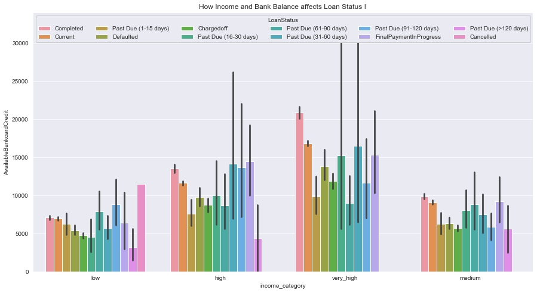

```python
# Visualizing the relationship of Loan Status to Available Bank Card Credit and Income category
plt.figure(figsize = (15,8))
ax = sb.barplot(data = df_prosper, x = "income_category", y = "AvailableBankcardCredit", hue = "LoanStatus")
ax.legend(loc = 2, ncol = 6, framealpha = 1, title = "LoanStatus")
plt.title("How Income and Bank Balance affects Loan Status I");
```

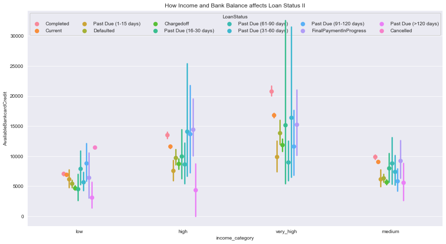

```python
# Visualizing the relationship of Loan Status to Available Bank Card Credit and Income category
plt.figure(figsize = (15,8))
ax = sb.pointplot(data = df_prosper, x = "income_category", y = "AvailableBankcardCredit", hue = "LoanStatus", dodge = 0.3, linestyles = "")
ax.legend(loc = 2, ncol = 6, framealpha = 1, title = "LoanStatus")
plt.title("How Income and Bank Balance affects Loan Status II");
```

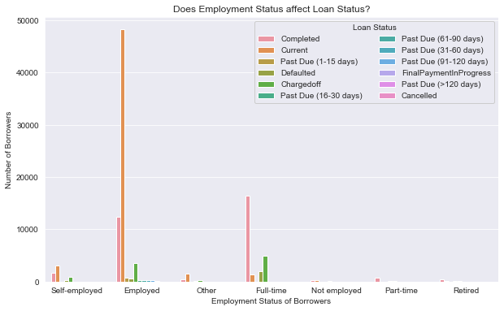

```python
# Visualizing the relationship between variables and Loan Status
plt.figure(figsize=(10,6))
sb.countplot(data = df_prosper, x = "EmploymentStatus", hue = "LoanStatus")
plt.legend(loc = 1, ncol = 2, framealpha = 1, title = "Loan Status")
plt.ylabel("Number of Borrowers")
plt.xlabel("Employment Status of Borrowers")
plt.title("Does Employment Status affect Loan Status?");
```